# R Notebook

# create connection to MySQL db

```r
library(DBI)
library(RMySQL)
# use readr to load csv file
library(readr)
# forces sqldf to use SQLite as its backing store
library(sqldf)
options(sqldf.driver = 'SQLite')

dbcon <- dbConnect(MySQL(), user = 'root', password = 'root',
                 dbname = 'bird_strike', host = 'localhost', port = 3306)
```

```sql
DROP TABLE IF EXISTS incidents;
```

```sql
DROP TABLE IF EXISTS airports;
```

```sql
DROP TABLE IF EXISTS conditions;
```

# Task1B: Create airports table

# The assumption is that using only airport_name can’t determine the whole record

# airports in different state may have same name

```sql
CREATE TABLE airports(
  aid INT PRIMARY KEY AUTO_INCREMENT,
  airport_name VARCHAR(50),
  airport_code VARCHAR(30) DEFAULT '',
  state VARCHAR(30)
);
```

# Task1D: Create conditions lookup table

# NOTE: ‘condition’ is the key word

```sql
CREATE TABLE conditions(
  cid INT PRIMARY KEY AUTO_INCREMENT,
  sky_conditions VARCHAR(30) UNIQUE,
  explanation VARCHAR(50) DEFAULT ''
);
```

# Task1A,C: Create incidents table

```sql
CREATE TABLE incidents(
  rid INT PRIMARY KEY,
  flight_date DATE,
  origin_id INT,
  airline VARCHAR(50),
  aircraft VARCHAR(30),
  flight_phase VARCHAR(30),
  altitude INT,
  condition_id INT,
  warning BOOLEAN,
  FOREIGN KEY(origin_id) REFERENCES airports(aid),
  FOREIGN KEY(condition_id) REFERENCES conditions(cid)
);
```

# ————————–

# Task2: populate tables

# load csv data

```r
bird_strikes <- read.csv("BirdStrikesData-V2.csv")
# remove all military flights(89 rows) -> 25469 rows
bird_strikes <- bird_strikes[!bird_strikes$airline == 'MILITARY',]
# remove records without flight information(aircraft,flight_date...) -> 25340 rows(129 rows removed)
# NOTE: '&' or '|' will evaluate the whole vector, while '&&' and '||' will only evaluate the first element
bird_strikes <- bird_strikes[!(bird_strikes$aircraft == '' & bird_strikes$flight_date == ''),]
bird_strikes
```

|  | rid | aircraft | airport | model | wildlife_struck | impact | flight_date | damage | airline | origin | flight_phase | remains_collected_flag | Remarks | wildlife_size | sky_conditions | species | pilot_warned_flag | altitude_ft | heavy_flag |
| --- | --- | --- | --- | --- | --- | --- | --- | --- | --- | --- | --- | --- | --- | --- | --- | --- | --- | --- | --- |
| 1 | 202152 | Airplane | LAGUARDIA NY | B-737-400 | 859 | Engine Shut Down | 11/23/2000 0:00 | Caused damage | US AIRWAYS* | New York | Climb | FALSE | FLT 753. PILOT REPTD A HUNDRED BIRDS ON UNKN TYPE. #1 ENG WAS SHUT DOWN AND DIVERTED TO EWR. SLIGHT VIBRATION. A/C WAS OUT OF SVC FOR REPAIRS TO COWLING, FAN DUCT ACCOUSTIC PANEL. INGESTION. DENTED FA… | Medium | No Cloud | Unknown bird - medium | N | 1,500 | Yes |
| 2 | 208159 | Airplane | DALLAS/FORT WORTH INTL ARPT | MD-80 | 424 | None | 7/25/2001 0:00 | Caused damage | AMERICAN AIRLINES | Texas | Landing Roll | FALSE | 102 CARCASSES FOUND. 1 LDG LIGHT ON NOSE GEAR WAS DAMAGED AND REPLACED. | Small | Some Cloud | Rock pigeon | Y | 0 | No |
| 3 | 207601 | Airplane | LAKEFRONT AIRPORT | C-500 | 261 | None | 9/14/2001 0:00 | No damage | BUSINESS | Louisiana | Approach | FALSE | FLEW UNDER A VERY LARGE FLOCK OF BIRDS OVER APCH END OF RWY. NO DMG. JUST A LOT OF BIRD DROPPINGS ON WINDSCREEN. | Small | No Cloud | European starling | N | 50 | No |
| 4 | 215953 | Airplane | SEATTLE-TACOMA INTL | B-737-400 | 806 | Precautionary Landing | 9/5/2002 0:00 | No damage | ALASKA AIRLINES | Washington | Climb | TRUE | NOTAM WARNING. 26 BIRDS HIT THE A/C, FORCING AN EMERGENCY LDG. 77 BIRDS WERE FOUND DEAD ON RWY/TWY WITH GRASSHOPPERS IN THEIR STOMACHS. SAFETY AREAS COULD NOT BE THOROUGHLY INSPCTD DURING 14 MINUTE SH… | Small | Some Cloud | European starling | Y | 50 | Yes |
| 5 | 219878 | Airplane | NORFOLK INTL | CL-RJ100/200 | 942 | None | 6/23/2003 0:00 | No damage | COMAIR AIRLINES | Virginia | Approach | FALSE | NO DMG REPTD. | Small | No Cloud | European starling | N | 50 | No |
| 6 | 218432 | Airplane | GUAYAQUIL/S BOLIVAR | A-300 | 537 | None | 7/24/2003 0:00 | No damage | AMERICAN AIRLINES | N/A | Take-off run | FALSE | NO DMG. BIRD REMAINS ON F/O WINDSCREEN. | Small | No Cloud | Unknown bird - small | N | 0 | No |
| 7 | 221697 | Airplane | NEW CASTLE COUNTY | LEARJET-25 | 227 | Other | 8/17/2003 0:00 | Caused damage | BUSINESS | Delaware | Climb | TRUE |  | Small | No Cloud | European starling | N | 150 | No |
| 8 | 236635 | Airplane | WASHINGTON DULLES INTL ARPT | A-320 | 320 | Other | 3/1/2006 0:00 | Caused damage | UNITED AIRLINES | DC | Approach | TRUE | WS ASSISTED IN CLEAN-UP OF 273 STARLINGS AND 1 BROWN-HEADED COWBIRD FROM RWY THRESHOLD. PHOTOS OF A/C TAKEN. BORESCOPED BOTH ENGS. FOUND DENTS AND NICKS IN STAGES 3-6. ALL WITHIN LIMITS. CLEANED RADOM… | Small | Some Cloud | European starling | Y | 100 | No |
| 9 | 207369 | Airplane | ATLANTA INTL | DC-9-30 | 9 | Aborted Take-off | 1/6/2000 0:00 | No damage | AIRTRAN AIRWAYS | Georgia | Take-off run | FALSE |  | Small | Some Cloud | Rock pigeon | N | 0 | No |
| 10 | 204371 | Airplane | ORLANDO SANFORD INTL AIRPORT | A-330 | 4 | None | 1/7/2000 0:00 | No damage | AIRTOURS INTL | Florida | Landing Roll | FALSE | FLT 057 | Small | Some Cloud | Unknown bird - small | N | 0 | No |

[output cut: 990 more lines]

# build airports data frame

```r
airports <- sqldf('SELECT DISTINCT airport AS airport_name, origin AS state
                    FROM bird_strikes
                    ORDER BY state')

# omit rows with airport_name be empty
# airports <- airports[!(airports$airport_name == ''),]

# if the state is N/A, the airport is not reside within USA, leave it empty
airports$state[airports$state == 'N/A'] <- ''
airports
```

| airport_name | state |
| --- | --- |
| BIRMINGHAM-SHUTTLESWORTH INTL | Alabama |
| TROY MUNICIPAL ARPT | Alabama |
| HUNTSVILLE INTL | Alabama |
| MONTGOMERY REGIONAL ARPT | Alabama |
| MOBILE DOWNTOWN ARPT | Alabama |
| MOBILE REGIONAL | Alabama |
| DEMOPOLIS MUNICIPAL ARPT | Alabama |
| PRYOR FIELD REGIONAL ARPT | Alabama |
| H L SONNY CALLAHAN ARPT | Alabama |
| BESSEMER ARPT | Alabama |

[output cut: 990 more lines]

# build conditions data frame

```r
conditions <- sqldf('SELECT DISTINCT sky_conditions FROM bird_strikes')
conditions
```

| sky_conditions |
| --- |
| No Cloud |
| Some Cloud |
| Overcast |

# populate airports table

```r
populate_airports <- function() {
  # iterate airports data frame
  for (i in 1:nrow(airports)) {
    # use "" to include value, value may contain ' \' '
    airport_name <- paste0('"', airports[i,1], '"')
    state <- paste0('"', airports[i,2], '"')
    cmd<-paste0('INSERT INTO airports(airport_name, state) VALUES (', airport_name, ',' , state, ')')
    dbExecute(dbcon,cmd)
  }
}

populate_airports()
```

# populate conditions table

```r
populate_conditions <- function() {
  # iterate conditions data frame
  for (i in 1:nrow(conditions)) {
    # use "" to include value
    sky_conditions <- paste0('"', conditions[i,1], '"')
    cmd<-paste0('INSERT INTO conditions(sky_conditions) VALUES (', sky_conditions, ')')
    dbExecute(dbcon,cmd)
  }
}

populate_conditions()
```

# this may take half a minute

```r
populate_incidents <- function() {
  # iterate incidents data frame
  # for (i in 1:10)
  for (i in 1:nrow(bird_strikes)){
    # rid
    rid <- bird_strikes[i, 1]
    # rid <- paste0('"', bird_strikes[i, 1], '"')

    # modify flight_date
    tmp_date <- strsplit(bird_strikes[i, 7], ' ')[[1]] # omid time
    tmp_date <- strsplit(tmp_date[[1]], '/')[[1]] # split y,m,d
    # MySQL permits a “relaxed” format for values specified as strings
    # for example, any punctuation chracter may be used as the delimiter;
    # moreover, it will autofill prefix 0 for month and day(1-9)
    flight_date <- paste(tmp_date[[3]], tmp_date[[1]], tmp_date[[2]], sep = '-')
    # flight_date <- paste(paste0('20', tmp_date[[3]]), tmp_date[[1]], tmp_date[[2]], sep = '-')
    flight_date <- paste0('"', flight_date, '"')

    # query airports table to get origin_id(aid),
    # both the airport_name and state name should be matched
    airport_name <- bird_strikes[i, 3]
    state <- bird_strikes[i, 10]
    # modify state with 'N/A' value to empty string
    if(state == 'N/A'){
      state <- ''
    }
    aid_query<-paste0('SELECT aid FROM airports WHERE airport_name =', '"', airport_name, '"', 'AND state =', '"', state, '"')
    aid <- dbGetQuery(dbcon, aid_query);
    origin_id <- aid[1, 1]

    # airline
    airline <- paste0('"', bird_strikes[i, 9], '"')

    # aircraft
    aircraft <- paste0('"', bird_strikes[i, 2], '"')

    # modify flight_phase
    # Assumption:
    # 1. 'Take-off run' belongs to takeoff phase
    # 2. 'Climb', 'Descent', 'Approach' belongs to inflight phase
    # 3. 'Landing Roll' belongs to landing phase
    # 4. 'Taxi' can be Taxi-out and Taxi-in; 'Parked' is at the very end of flight phase
    #    thus they belongs to unknown phase
    flight_phase <- bird_strikes[i, 11]
    if(flight_phase == 'Take-off run'){
      flight_phase <- 'takeoff'
    } else if (flight_phase == 'Climb' | flight_phase == 'Descent' | flight_phase == 'Approach'){
      flight_phase <- 'inflight'
    } else if (flight_phase == 'Landing Roll'){
      flight_phase <- 'landing'
    } else {
      # Taxi && Parked
      flight_phase <- 'unknown'
    }
    flight_phase <- paste0('"', flight_phase, '"')

    # altitude, no need to include it with ""
    altitude_str <- bird_strikes[i, 18]
    # get the first splitted subset
    splitted_str <- strsplit(altitude_str, ',')[[1]]
    altitude <- ''
    # convert '1,500' into '1500'
    for(str in splitted_str){
      altitude <- paste0(altitude, str)
    }

    # query conditions table to get condition_id(cid)
    cid_query<-paste0('SELECT cid FROM conditions WHERE sky_conditions=', '"', bird_strikes[i, 15], '"')
    cid <- dbGetQuery(dbcon, cid_query);
    condition_id <- cid[1, 1]

    # warning, no need to include it with ""
    warning <- bird_strikes[i, 17]
    if(warning == 'N'){
      warning <- 'FALSE'
    } else {
      warning <- 'TRUE'
    }

    # execute statement
    cmd<-paste0('INSERT INTO incidents VALUES (', rid, ',', flight_date, ',', origin_id, ',', airline, ',', aircraft, ',',
                flight_phase, ',', altitude, ',', condition_id, ',', warning, ')')
    dbExecute(dbcon,cmd)
  }
}

populate_incidents()
```

# ———————————————————————————

# Task3: Show that the loading of the data worked by displaying parts of each table

# (do not show the entire tables).

# leave airport_code attribute empty for future expansion

```sql
SELECT * FROM airports LIMIT 50;
```

| aid | airport_name | airport_code | state |
| --- | --- | --- | --- |
| 1 | BIRMINGHAM-SHUTTLESWORTH INTL |  | Alabama |
| 2 | TROY MUNICIPAL ARPT |  | Alabama |
| 3 | HUNTSVILLE INTL |  | Alabama |
| 4 | MONTGOMERY REGIONAL ARPT |  | Alabama |
| 5 | MOBILE DOWNTOWN ARPT |  | Alabama |
| 6 | MOBILE REGIONAL |  | Alabama |
| 7 | DEMOPOLIS MUNICIPAL ARPT |  | Alabama |
| 8 | PRYOR FIELD REGIONAL ARPT |  | Alabama |
| 9 | H L SONNY CALLAHAN ARPT |  | Alabama |
| 10 | BESSEMER ARPT |  | Alabama |

[output cut: 40 more lines]

# conditions table(only 3 records, show the entire table)

# leave the explanation attribute empty for future expansion

```sql
SELECT * FROM conditions;
```

| cid | sky_conditions | explanation |
| --- | --- | --- |
| 1 | No Cloud |  |
| 2 | Some Cloud |  |
| 3 | Overcast |  |

# incidents table

```sql
SELECT * FROM incidents LIMIT 50;
```

| rid | flight_date | origin_id | airline | aircraft | flight_phase | altitude | condition_id | warning |
| --- | --- | --- | --- | --- | --- | --- | --- | --- |
| 200011 | 2000-04-06 | 852 | ABX AIR | Airplane | landing | 0 | 3 | 1 |
| 200012 | 2000-04-10 | 696 | AIR MIDWEST | Airplane | landing | 0 | 3 | 1 |
| 200022 | 2000-02-28 | 947 | AMERICAN EAGLE AIRLINES | Airplane | inflight | 2000 | 1 | 1 |
| 200023 | 2000-08-25 | 210 | US AIRWAYS* | Airplane | inflight | 7000 | 1 | 0 |
| 200028 | 2000-03-22 | 355 | UNITED AIRLINES | Airplane | inflight | 3000 | 1 | 1 |
| 200029 | 2000-05-14 | 432 | BUSINESS EXPRESS | Airplane | inflight | 30 | 1 | 1 |
| 200031 | 2000-06-12 | 171 | GREAT LAKES AIRLINES | Airplane | inflight | 500 | 1 | 0 |
| 200036 | 2000-09-29 | 703 | BUSINESS | Airplane | inflight | 1000 | 1 | 0 |
| 200037 | 2001-02-01 | 94 | UNITED AIRLINES | Airplane | takeoff | 0 | 2 | 1 |
| 200042 | 2000-08-31 | 13 | FEDEX EXPRESS | Airplane | inflight | 400 | 2 | 0 |

[output cut: 40 more lines]

# display joint tables

```sql
SELECT * FROM incidents i
  JOIN airports a ON i.origin_id = a.aid
  JOIN conditions c ON c.cid = i.condition_id
  ORDER BY rid
  LIMIT 50;
```

| rid | flight_date | origin_id | airline | aircraft | flight_phase | altitude | condition_id | warning | aid | airport_name | airport_code | state | cid | sky_conditions | explanation |
| --- | --- | --- | --- | --- | --- | --- | --- | --- | --- | --- | --- | --- | --- | --- | --- |
| 200011 | 2000-04-06 | 852 | ABX AIR | Airplane | landing | 0 | 3 | 1 | 852 | PORTLAND INTL (OR) |  | Oregon | 3 | Overcast |  |
| 200012 | 2000-04-10 | 696 | AIR MIDWEST | Airplane | landing | 0 | 3 | 1 | 696 | EPPLEY AIRFIELD |  | Nebraska | 3 | Overcast |  |
| 200022 | 2000-02-28 | 947 | AMERICAN EAGLE AIRLINES | Airplane | inflight | 2000 | 1 | 1 | 947 | DALLAS/FORT WORTH INTL ARPT |  | Texas | 1 | No Cloud |  |
| 200023 | 2000-08-25 | 210 | US AIRWAYS* | Airplane | inflight | 7000 | 1 | 0 | 210 | PENSACOLA REGIONAL |  | Florida | 1 | No Cloud |  |
| 200028 | 2000-03-22 | 355 | UNITED AIRLINES | Airplane | inflight | 3000 | 1 | 1 | 355 | DES MOINES INTL |  | Iowa | 1 | No Cloud |  |
| 200029 | 2000-05-14 | 432 | BUSINESS EXPRESS | Airplane | inflight | 30 | 1 | 1 | 432 | LOGAN INTL |  | Massachusetts | 1 | No Cloud |  |
| 200031 | 2000-06-12 | 171 | GREAT LAKES AIRLINES | Airplane | inflight | 500 | 1 | 0 | 171 | DENVER INTL AIRPORT |  | Colorado | 1 | No Cloud |  |
| 200036 | 2000-09-29 | 703 | BUSINESS | Airplane | inflight | 1000 | 1 | 0 | 703 | NORFOLK REGIONAL ARPT |  | Nebraska | 1 | No Cloud |  |
| 200037 | 2001-02-01 | 94 | UNITED AIRLINES | Airplane | takeoff | 0 | 2 | 1 | 94 | SAN FRANCISCO INTL ARPT |  | California | 2 | Some Cloud |  |
| 200042 | 2000-08-31 | 13 | FEDEX EXPRESS | Airplane | inflight | 400 | 2 | 0 | 13 | TED STEVENS ANCHORAGE INTL |  | Alaska | 2 | Some Cloud |  |

[output cut: 40 more lines]

# —————————————————————–

# Task4: find the top-10 airlines with the most number of incidents.

```sql
SELECT airline, COUNT(rid) AS total FROM incidents
  GROUP BY airline
  ORDER BY total DESC
  LIMIT 10;
```

| airline | total |
| --- | --- |
| SOUTHWEST AIRLINES | 4628 |
| BUSINESS | 3074 |
| AMERICAN AIRLINES | 2058 |
| DELTA AIR LINES | 1349 |
| AMERICAN EAGLE AIRLINES | 932 |
| SKYWEST AIRLINES | 891 |
| US AIRWAYS* | 797 |
| JETBLUE AIRWAYS | 708 |
| UPS AIRLINES | 590 |
| US AIRWAYS | 540 |

# ———————————————————————————–

# Task5: find the flight phase that had an above average number bird strike incidents

# (during any flight phase).

# NOTE: MySQL requires the derived table to have its own alias

```sql
SELECT flight_phase, COUNT(rid) AS total FROM incidents AS i
  GROUP BY flight_phase
  HAVING total > (SELECT AVG(cnt)
                    FROM (SELECT COUNT(rid) AS cnt
                            FROM incidents
                            GROUP BY flight_phase) AS sub);
```

| flight_phase | total |
| --- | --- |
| inflight | 15523 |

# only for testing, not the answer of Task5

```sql
SELECT flight_phase, COUNT(rid) AS cnt FROM incidents
    GROUP BY flight_phase;
```

```sql
SELECT AVG(cnt) AS average FROM (SELECT COUNT(rid) AS cnt
                                    FROM incidents
                                    GROUP BY flight_phase) AS sub;
```

# ———————————————————————————–

# Task6:find the maximum number of bird strike incidents by month (across all years).

# Include all airlines and all flights.

# This query can help answer the question which month, historically, is the most dangerous for bird strikes.

```sql
SELECT SUBSTR(flight_date, 6, 2) AS month, COUNT(rid) AS total FROM incidents
  GROUP BY month
  HAVING total = (SELECT MAX(cnt)
                    FROM (SELECT COUNT(rid) AS cnt FROM incidents
                            GROUP BY SUBSTR(flight_date, 6, 2)) AS sub);
```

| month | total |
| --- | --- |
| 08 | 3704 |

# only for testing, not the answer of Task6

```sql
SELECT SUBSTR(flight_date, 6, 2) AS month, COUNT(rid) AS total FROM incidents
  GROUP BY month
  ORDER BY month;
```

```sql
SELECT MAX(cnt) FROM (SELECT COUNT(rid) AS cnt FROM incidents
                        GROUP BY SUBSTR(flight_date, 6, 2)) AS sub;
```

# ————————————————————————————————————

# Task7: Build a column chart that visualizes the number of bird strikes incidents per year from 2005 to 2011.

# Adorn the graph with appropriate axis labels, titles, legend, data labels, etc.

```r
# import ggplot2 library for drawing column graph
library(ggplot2)
cmd <- "SELECT SUBSTR(flight_date, 1, 4) AS year, COUNT(rid) as total FROM incidents
          GROUP BY year
          HAVING year >= '2005' AND year <= '2011'
          ORDER BY year;"
rs <- dbGetQuery(dbcon, cmd)
rs
```

| year | total |
| --- | --- |
| 2005 | 1853 |
| 2006 | 2159 |
| 2007 | 2301 |
| 2008 | 2258 |
| 2009 | 3247 |
| 2010 | 3121 |
| 2011 | 2952 |

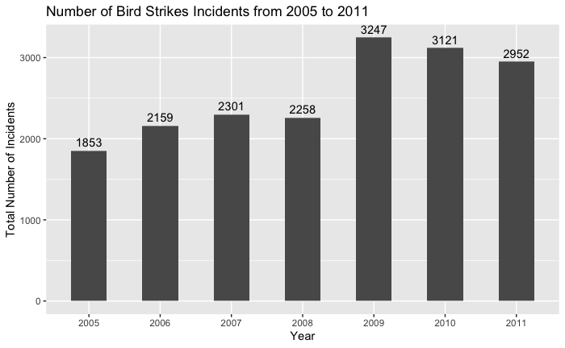

```r
# set the stat = 'identity' tells ggplot2 that the y-value is provided
# instead of counting the # of rows for x-value
# add column bar, data labels
graph <- ggplot(rs, aes(x = year, y = total)) + geom_bar(stat='identity', width = 0.5) + geom_text(aes(label = total), vjust = -0.5)
# add axis labels, titles
graph <- graph + labs(title = 'Number of Bird Strikes Incidents from 2005 to 2011',
                      x = 'Year', y = 'Total Number of Incidents')
graph
```

# only for testing, not the answer of Task7

```sql
SELECT SUBSTR(flight_date, 1, 4) AS year, COUNT(rid) as total FROM incidents
  GROUP BY year
  HAVING year >= '2005' AND year <= '2011'
  ORDER BY year;
```

# ———————————————————————————–

# Task8: Create a stored procedure in MySQL that adds a new incident to the database.

# You may decide what you need to pass to the stored procedure to add a bird strike incident

# and you must account for there being potentially a new airport.

# After insertion, show (in R) that your procedure worked.

```sql
DROP PROCEDURE IF EXISTS insert_incident_data;
```

# create stored procedure

```sql
CREATE PROCEDURE insert_incident_data(
  IN rid INT,
  IN flight_date DATE,
  IN origin_id INT,
  IN airline VARCHAR(50),
  IN aircraft VARCHAR(30),
  IN flight_phase VARCHAR(30),
  IN altitude INT,
  IN condition_id INT,
  IN warning BOOLEAN
)
BEGIN
    DECLARE originCnt INT;
    DECLARE conditionCnt INT;

    SELECT COUNT(aid) INTO originCnt
      FROM airports
      WHERE aid = origin_id;

  SELECT COUNT(cid) INTO conditionCnt
      FROM conditions
      WHERE cid = condition_id;

    -- check if origin_id and condition_id exists
    IF originCnt != 1 THEN
      -- '45000' unhandled user-defined exception.
        SIGNAL SQLSTATE '45000'
            SET MESSAGE_TEXT = 'Origin id not found in airports table';
    ELSEIF conditionCnt != 1 THEN
    SIGNAL SQLSTATE '45000'
            SET MESSAGE_TEXT = 'Condition id not found in conditions table';
  ELSE
    -- no conflicts, insert data into incidents table
    INSERT INTO incidents
      VALUES (rid, flight_date, origin_id, airline, aircraft, flight_phase, altitude, condition_id, warning);
    END IF;

END
```

# insert data with new(non-exist) origin_id

# Error ‘Origin id not found in airports table’ will appear

```
Error in .local(conn, statement, ...) :
  could not run statement: Origin id not found in airports table
Failed to execute SQL chunk
```

# insert data with new(non-exist) condition_id

# Error ‘Condition id not found in conditions table’ will appear

```
Error in .local(conn, statement, ...) :
  could not run statement: Condition id not found in conditions table
Failed to execute SQL chunk
```

# insert data with valid values

```sql
CALL insert_incident_data(3, '2005-11-01', 765, 'test airline3', 'test aircraft3', 'takeoff', 0, 1, FALSE);
```

# show new inserted data

```sql
SELECT * FROM incidents i
  JOIN airports a ON i.origin_id = a.aid
  JOIN conditions c ON i.condition_id = c.cid
  WHERE rid = 3;
```

| rid | flight_date | origin_id | airline | aircraft | flight_phase | altitude | condition_id | warning | aid | airport_name | airport_code | state | cid | sky_conditions | explanation |
| --- | --- | --- | --- | --- | --- | --- | --- | --- | --- | --- | --- | --- | --- | --- | --- |
| 3 | 2005-11-01 | 765 | test airline3 | test aircraft3 | takeoff | 0 | 1 | 0 | 765 | CLINTON COUNTY ARPT |  | New York | 1 | No Cloud |  |

# disconnect

```r
dbDisconnect(dbcon)
```

```
[1] TRUE
```